# Loan Default Detection

### 2 SHAP

- Lead:
  - SHAP value is a united approach to explain the output of any machine learning model.
  - SHAP value connects game theory with local explanations, uniting several previous mothods and representing the only possible consistent and locally accurate additive feature attribution method based on expectations.
  - Three important benefits of SHAP value are introduced below:
    - Global interpretability: The collective SHAP values can show how much each predictor contributes, either positively or negatively, to the target variable.
    - Local interpretability: Each observation gets its own set of SHAP values, which greatly increases its transparency and enables us to pinpoint and contrast the impacts of the factors
    - SHAP values can be calculated for any tree-based model, while other models use linear regression or logistic regression mdoels as the surrogate models
- Analysis
  - Build a random forest model and use the TreeExplainer in SHAP
  - Use shap.summary_plot function with plot_type = 'bar' to plot varaible importance, which take the mean absolute value of the SHAP values for each feature to get a standard bar plot
  - Using SHAP calue to get the plot which show positive and negative relationships of the predictions with the trarget variable
  - Use shap.dependence_plot to generate the dependent plot, which will show whether the relationship between the target and a feature is linear, monotonic or more complex.
  - Use initjs() to initialize and get the individual SHAP value plot
- Python code: Attached below

```python
# load packages
from sklearn.model_selection import train_test_split
from sklearn import preprocessing
from sklearn.ensemble import RandomForestRegressor
```

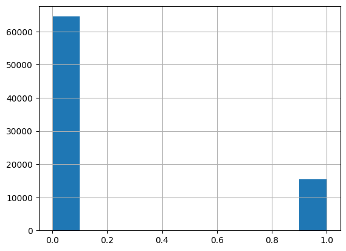

```python
loan_woe['loan_default'].hist()
```

```python
# split the sample dataset
Y = df['loan_default']
X = df[main_predictors]
```

```python
X_train, X_test, Y_train, Y_test = train_test_split(X, Y, test_size = 0.2)
```

```python
model = RandomForestRegressor(max_depth=6, random_state=0, n_estimators=10)
model.fit(X_train, Y_train)
print(model.feature_importances_)
```

```
[0.33470778 0.17480121 0.02962729 0.0570153  0.07098893 0.01753034
 0.04250526 0.01702139 0.02037794 0.01738453 0.02967226 0.01409989
 0.01224345 0.00713003 0.0065319  0.02028785 0.01477897 0.02296433
 0.00324312 0.01227168 0.00638877 0.02519989 0.00358631 0.01549837
 0.02414321]
```

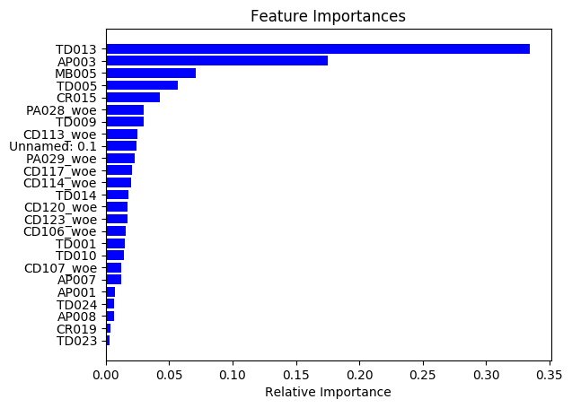

```python
importances = model.feature_importances_
indices = np.argsort(importances)

features = X_train.columns
plt.title('Feature Importances')
plt.barh(range(len(indices)), importances[indices], color='b', align='center')
plt.yticks(range(len(indices)), [features[i] for i in indices])
plt.xlabel('Relative Importance')
plt.show()
```

- Conclusion
  - The plot shown above tell us the relative importance of each variables. As we can see, the top 5 important varaibles are TD013, AP003, MB005, TD005, and CR015.

### 2.1 Variable Importance Plot - Global Interpretability

```python
import shap
```

```python
shap_values = shap.TreeExplainer(model).shap_values(X_train)
```

```python
# Determine the correlation in order to plot with different colors
corrlist = np.zeros( len(features))
X_train_np = X_train.to_numpy() # our X_train is a pandas data frame. Convert it to numpy
for i in range(0,len(features) ):
    tmp = np.corrcoef(shap_values[:,i],X_train_np[:,i])
    corrlist[i] = tmp[0][1]
```

```python
shap_v_abs = np.abs(shap_values)
shap_v_abs.mean()
```

```
0.006162684324090295
```

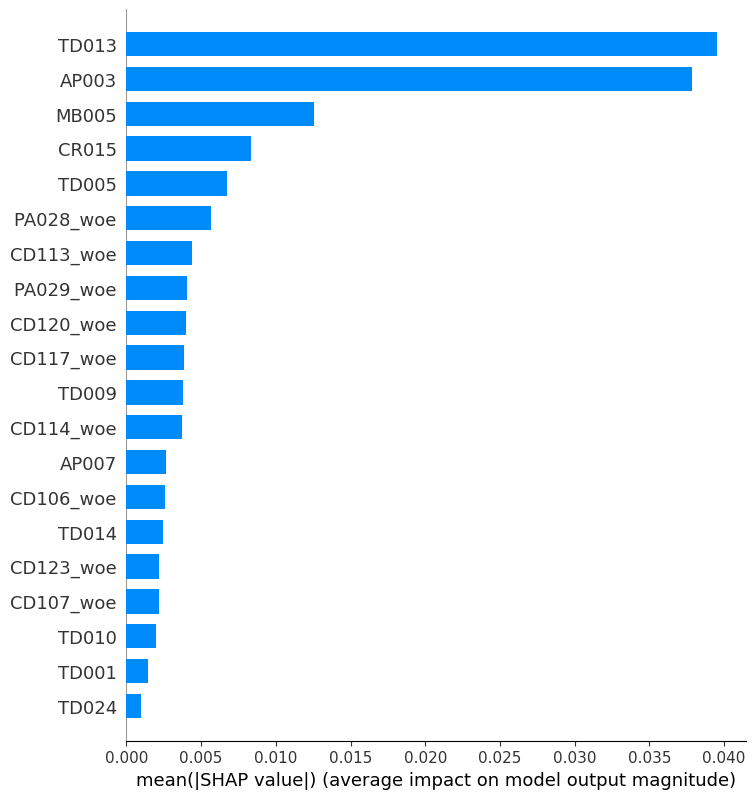

```python
# variable importance plot
shap.summary_plot(shap_values, X_train, plot_type="bar")
```

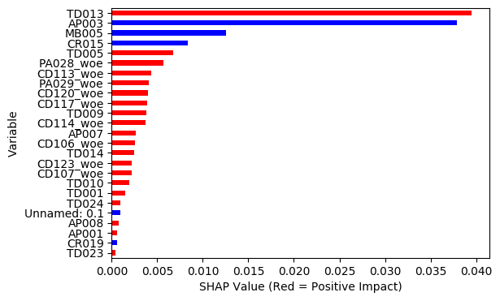

```python
# variable importance with positive and negative relationship
def ABS_SHAP(df_shap,df):
    #import matplotlib as plt
    # Make a copy of the input data
    shap_v = pd.DataFrame(df_shap)
    feature_list = df.columns
    shap_v.columns = feature_list
    df_v = df.copy().reset_index().drop('index',axis=1)

    # Determine the correlation in order to plot with different colors
    corr_list = list()
    for i in feature_list:
        b = np.corrcoef(shap_v[i],df_v[i])[1][0]
        corr_list.append(b)
    corr_df = pd.concat([pd.Series(feature_list),pd.Series(corr_list)],axis=1).fillna(0)
    # Make a data frame. Column 1 is the feature, and Column 2 is the correlation coefficient
    corr_df.columns  = ['Variable','Corr']
    corr_df['Sign'] = np.where(corr_df['Corr']>0,'red','blue')

    # Plot it
    shap_abs = np.abs(shap_v)
    k=pd.DataFrame(shap_abs.mean()).reset_index()
    k.columns = ['Variable','SHAP_abs']
    k2 = k.merge(corr_df,left_on = 'Variable',right_on='Variable',how='inner')
    k2 = k2.sort_values(by='SHAP_abs',ascending = True)
    colorlist = k2['Sign']
    ax = k2.plot.barh(x='Variable',y='SHAP_abs',color = colorlist, figsize=(6,4),legend=False)
    ax.set_xlabel("SHAP Value (Red = Positive Impact)")

ABS_SHAP(shap_values,X_train)
```

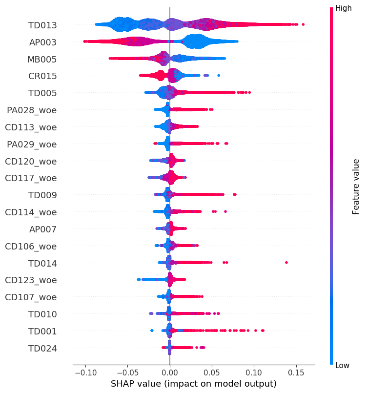

```python
# summarize the effects of all the features
shap.summary_plot(shap_values, X_train)
```

- Conclusion
  - Among these three plots, the first one just shows us the feature importance, the second one provides more information of whether the variable has positive or negative realtionship with the target variable. As for the last plot, except showing the feature importance which told by the vertical location, the horizontal location shows whether the effect of that value caused a higher or lower prediction and color shows whether that feature was high or low for that observation.
  - I have mentioned the top 5 important variables in my previous conclusion. At this point, we can see features such as TD013, TD005, and PA028 have a positive impact while variables such as AP003, MB005, and CR015 have a negative impact. That is to say, TD013, TD005, and PA028 will increase the probability of loan default while AP003, MB005, and CR015 will decrease the probability of loan default.
  - As a result, for loan providers who will have previous background investigation for people who need loans, they should spend more time to explore individuals' information related to TD013, TD005, and PA028, etc. Meanwhile, they can offer convenience who have a good situations in AP003, MB005, and CR015.
  - The result aligns with the variable dictionary, those factors will decrease the likelihood of loan default are education level, years of phone active, and monthly max creadit card mob.